[figure not shown]

## Demostration Class 01

# A Fast (and Furious) Introduction to Python

### Luis Martí, LIRA/[DEE](http://www.ele.puc-rio.br)/[PUC-Rio](http://www.puc-rio.br)

http://lmarti.com; lmarti@ele.puc-rio.br

[Advanced Evolutionary Computation: Theory and Practice](http://lmarti.com/aec-2014)

> This notebook is based on Rick Muller's [A Crash Course in Python for Scientists](http://nbviewer.ipython.org/gist/rpmuller/5920182)

The notebook is better viewed rendered as slides. You can convert it to slides and view them by:

- using [nbconvert](http://ipython.org/ipython-doc/1/interactive/nbconvert.html) with a command like:

  ```bash
  $ ipython nbconvert --to slides --post serve <this-notebook-name.ipynb>
  ```

- installing [Reveal.js - Jupyter/IPython Slideshow Extension](https://github.com/damianavila/live_reveal)
- using the online [IPython notebook slide viewer](https://slideviewer.herokuapp.com/) (some slides of the notebook might not be properly rendered).

This and other related IPython notebooks can be found at the course github repository:

- https://github.com/lmarti/evolutionary-computation-course

# A fair question: Why Python?

- Multi-platform language.
- object-oriented,
- imperative and
- functional programming or
- procedural styles.
- dynamic type system
- automatic memory management
- large and comprehensive standard library.

## Python works out of the box

Many of the things I used to use a calculator for, I now use Python for:

```python
23423+4345
```

```python
(50-5*6)/4
```

## There are some gotchas compared to using a normal calculator.

```python
7/3
```

Python integer division, like C or Fortran integer division, truncates the remainder and returns an integer. At least it does in version 2. In version 3, Python returns a floating point number. You can get a sneak preview of this feature in Python 2 by importing the module from the future features:

```
from __future__ import division
```

Alternatively, you can convert one of the integers to a floating point number, in which case the division function returns another floating point number.

```python
7/3.
```

```python
7/float(3)
```

# The import statement

```python
sqrt(83)
```

or you can simply import the math library itself

```python
import math
math.sqrt(81)
```

You can define variables using the equals (=) sign:

```python
width = 20
length = 30
area = length*width
area
```

If you try to access a variable that you haven't yet defined, you get an error:

```python
volume
```

and you need to define it:

```python
depth = 10
volume = area*depth
volume
```

You can name a variable *almost* anything you want. It needs to start with an alphabetical character or "_", can contain alphanumeric charcters plus underscores ("_"). Certain words, however, are reserved for the language:

```
and, as, assert, break, class, continue, def, del, elif, else, except,
exec, finally, for, from, global, if, import, in, is, lambda, not, or,
pass, print, raise, return, try, while, with, yield
```

Trying to define a variable using one of these will result in a syntax error:

```python
return = 0
```

## Strings

Strings are lists of printable characters, and can be defined using either single quotes

```python
'Hello, World!'
```

or double quotes

```python
"Hello, World!"
```

But not both at the same time, unless you want one of the symbols to be part of the string.

```python
"He's a Rebel"
```

```python
'''fasdfasdf
dsfasd
fasdf
asdfasdf'''
```

Just like the other two data objects we're familiar with (ints and floats), you can assign a string to a variable

```python
greeting = "Hello, World!"
```

The **print** statement is often used for printing character strings:

```python
print greeting
```

```python
print("The area is ")
```

You can use the + operator to concatenate strings together:

```python
statement = "Hello," + "World!"
print statement
```

Don't forget the space between the strings, if you want one there.

```python
statement = "Hello, " + "World!"
print statement
```

You can use + to concatenate multiple strings in a single statement:

```python
print "This " + "is " + "a " + "longer " + "statement."
```

If you have a lot of words to concatenate together, there are other, more efficient ways to do this. But this is fine for linking a few strings together.

## Lists

Very often in a programming language, one wants to keep a group of similar items together. Python does this using a data type called **lists**.

```python
days_of_the_week = ["Sunday","Monday","Tuesday","Wednesday","Thursday","Friday","Saturday"]
```

You can access members of the list using the **index** of that item:

```python
days_of_the_week[2]
```

Python lists, like C, but unlike Fortran, use 0 as the index of the first element of a list. Thus, in this example, the 0 element is "Sunday", 1 is "Monday", and so on. If you need to access the *n*th element from the end of the list, you can use a negative index. For example, the -1 element of a list is the last element:

```python
days_of_the_week[-1]
```

You can add additional items to the list using the `.append()` command:

```python
languages = ["Fortran","C","C++"]
languages.append("Python")
print languages
```

The `range()` command is a convenient way to make sequential lists of numbers:

```python
range(10)
```

Note that `range(n)` starts at 0 and gives the sequential list of integers less than n. If you want to start at a different number, use `range(start,stop)`.

```python
range(2,8)
```

The lists created above with range have a *step* of 1 between elements. You can also give a fixed step size via a third command:

```python
evens = range(0,20,2)
evens
```

```python
evens[3]
```

You can find out how long a list is using the **len()** command:

```python
len(evens)
```

## Lists do not have to hold the same data type. For example,

```python
["Today",7,99.3,""]
```

However, it's good (but not essential) to use lists for similar objects that are somehow logically connected. If you want to group different data types together into a composite data object, it's best to use **tuples**, which we will learn about below.

## Iteration, Indentation, and Blocks

One of the most useful things you can do with lists is to *iterate* through them, i.e. to go through each element one at a time. To do this in Python, we use the **for** statement:

```python
for day in days_of_the_week:
    print day
```

```python
for day in days_of_the_week:
    statement = "Today is " + day
    print statement
```

The **range()** command is particularly useful with the **for** statement to execute loops of a specified length:

```python
for i in range(20):
    print "The square of ",i," is ",i*i
```

## Slicing

Lists and strings have something in common that you might not suspect: they can both be treated as sequences. You already know that you can iterate through the elements of a list. You can also iterate through the letters in a string:

```python
for letter in "Sunday":
    print letter
```

If we want the list containing the first two elements of a list, we can do this via

```python
days_of_the_week[0:2]
```

or simply

```python
days_of_the_week[:2]
```

If we want the last items of the list, we can do this with negative slicing:

```python
days_of_the_week[-2:]
```

which is somewhat logically consistent with negative indices accessing the last elements of the list.

You can do:

```python
workdays = days_of_the_week[1:6]
print workdays
```

Since strings are sequences, you can also do this to them:

```python
day = "Sunday"
abbreviation = day[:3]
print abbreviation
```

If we really want to get fancy, we can pass a third element into the slice, which specifies a step length (just like a third argument to the **range()** function specifies the step):

```python
numbers = range(0,40)
evens = numbers[2::2]
evens
```

Note that in this example I was even able to omit the second argument, so that the slice started at 2, went to the end of the list, and took every second element, to generate the list of even numbers less that 40.

## Booleans and Truth Testing

We have now learned a few data types. We have integers and floating point numbers, strings, and lists to contain them. We have also learned about lists, a container that can hold any data type. We have learned to print things out, and to iterate over items in lists. We will now learn about **boolean** variables that can be either True or False.

We invariably need some concept of *conditions* in programming to control branching behavior, to allow a program to react differently to different situations. If it's Monday, I'll go to work, but if it's Sunday, I'll sleep in. To do this in Python, we use a combination of **boolean** variables, which evaluate to either True or False, and **if** statements, that control branching based on boolean values.

For example:

```python
day = "Sunday"
if day == None:
    print "Sleep in"
else:
    print "Go to work"
```

(Quick quiz: why did the snippet print "Go to work" here? What is the variable "day" set to?)

Let's take the snippet apart to see what happened. First, note the statement

```python
day == "Sunday"
```

```python
1 == 2
```

```python
50 == 2*25
```

```python
3 < 3.14159
```

```python
1 == 1.0
```

```python
1 != 0
```

```python
1 <= 2
```

```python
1 >= 1
```

We see a few other boolean operators here, all of which which should be self-explanatory. Less than, equality, non-equality, and so on.

Particularly interesting is the 1 == 1.0 test, which is true, since even though the two objects are different data types (integer and floating point number), they have the same *value*. There is another boolean operator **is**, that tests whether two objects are the same object:

```python
1 is 1.0
```

We can do boolean tests on lists as well:

```python
[1,2,3] == [1,2,4]
```

```python
[1,2,3] < [1,2,4]
```

Finally, note that you can also string multiple comparisons together, which can result in very intuitive tests:

```python
hours = 5
0 < hours < 24
```

#### If statements can have **elif** parts ("else if"), in addition to if/else parts. For example:

```python
if day == "Sunday":
    print "Sleep in"
elif day == "Saturday":
    print "Do chores"
else:
    print "Go to work"
```

Of course we can combine if statements with for loops, to make a snippet that is almost interesting:

```python
for day in days_of_the_week:
    statement = "Today is " + day
    print statement
    if day == "Sunday":
        print "   Sleep in"
    elif day == "Saturday":
        print "   Do chores"
    else:
        print "   Go to work"
```

This is something of an advanced topic, but ordinary data types have boolean values associated with them, and, indeed, in early versions of Python there was not a separate boolean object. Essentially, anything that was a 0 value (the integer or floating point 0, an empty string "", or an empty list []) was False, and everything else was true. You can see the boolean value of any data object using the **bool()** function.

```python
bool(1)
```

```python
bool(0)
```

```python
bool(["This "," is "," a "," list"])
```

## Code Example: The Fibonacci Sequence

The [Fibonacci sequence](http://en.wikipedia.org/wiki/Fibonacci_number) is a sequence in math that starts with 0 and 1, and then each successive entry is the sum of the previous two. Thus, the sequence goes 0,1,1,2,3,5,8,13,21,34,55,89,...

A very common exercise in programming books is to compute the Fibonacci sequence up to some number **n**. First I'll show the code, then I'll discuss what it is doing.

```python
n = 10
sequence = [0,1]
for i in range(2,n): # This is going to be a problem if we ever set n <= 2!
    sequence.append(sequence[i-1]+sequence[i-2])
print sequence
```

```
[0, 1, 1, 2, 3, 5, 8, 13, 21, 34]
```

## Functions

We might want to use the Fibonacci snippet with different sequence lengths. We could cut an paste the code into another cell, changing the value of **n**, but it's easier and more useful to make a function out of the code. We do this with the **def** statement in Python:

```python
def fibonacci(sequence_length):
    "Return the Fibonacci sequence of length *sequence_length*"
    sequence = [0,1]
    if sequence_length < 1:
        print "Fibonacci sequence only defined for length 1 or greater"
        return
    if 0 < sequence_length < 3:
        return sequence[:sequence_length]
    for i in range(2,sequence_length):
        sequence.append(sequence[i-1]+sequence[i-2])
    return sequence
```

We can now call **fibonacci()** for different sequence_lengths:

```python
fibonacci(12)
```

We've introduced a several new features here. First, note that the function itself is defined as a code block (a colon followed by an indented block). This is the standard way that Python delimits things. Next, note that the first line of the function is a single string. This is called a **docstring**, and is a special kind of comment that is often available to people using the function through the python command line:

```python
help(math)
```

If you define a docstring for all of your functions, it makes it easier for other people to use them, since they can get help on the arguments and return values of the function.

Next, note that rather than putting a comment in about what input values lead to errors, we have some testing of these values, followed by a warning if the value is invalid, and some conditional code to handle special cases.

## Recursion and Factorials

Functions can also call themselves, something that is often called *recursion*. We're going to experiment with recursion by computing the factorial function. The factorial is defined for a positive integer **n** as

$$ n! = n(n-1)(n-2)\cdots 1 $$

First, note that we don't need to write a function at all, since this is a function built into the standard math library. Let's use the help function to find out about it:

```python
from math import factorial
help(factorial)
```

This is clearly what we want.

```python
factorial(20)
```

However, if we did want to write a function ourselves, we could do recursively by noting that

$$ n! = n(n-1)!$$

The program then looks something like:

```python
def fact(n):
    if n <= 0:
        return 1
    return n*fact(n-1)
```

```python
fact(20)
```

Recursion can be very elegant, and can lead to very simple programs.

## Two More Data Structures: Tuples and Dictionaries

Before we end the Python overview, I wanted to touch on two more data structures that are very useful (and thus very common) in Python programs.

A **tuple** is a sequence object like a list or a string. It's constructed by grouping a sequence of objects together with commas, either without brackets, or with parentheses:

```python
t = (1,2,'hi',9.0)
t
```

Tuples are like lists, in that you can access the elements using indices:

```python
t[1]
```

However, tuples are *immutable*, you can't append to them or change the elements of them:

```python
t.append(7)
```

```python
t[1]=77
```

Tuples are useful anytime you want to group different pieces of data together in an object, but don't want to create a full-fledged class (see below) for them. For example, let's say you want the Cartesian coordinates of some objects in your program. Tuples are a good way to do this:

```python
('Bob',0.0,21.0)
```

Again, it's not a necessary distinction, but one way to distinguish tuples and lists is that tuples are a collection of different things, here a name, and x and y coordinates, whereas a list is a collection of similar things, like if we wanted a list of those coordinates:

```python
positions = [
             ('Bob',0.0,21.0),
             ('Cat',2.5,13.1),
             ('Dog',33.0,1.2)
             ]
```

Tuples can be used when functions return more than one value. Say we wanted to compute the smallest x- and y-coordinates of the above list of objects. We could write:

```python
def minmax(objects):
    minx = 1e20 # These are set to really big numbers
    miny = 1e20
    for obj in objects:
        name,x,y = obj
        if x < minx:
            minx = x
        if y < miny:
            miny = y
    return minx,miny

x,y = minmax(positions)
print x,y
```

Here we did two things with tuples you haven't seen before. First, we unpacked an object into a set of named variables using *tuple assignment*:

```
>>> name,x,y = obj
```

We also returned multiple values (minx,miny), which were then assigned to two other variables (x,y), again by tuple assignment. This makes what would have been complicated code in C++ rather simple.

Tuple assignment is also a convenient way to swap variables:

```python
x,y = 1,2
y,x = x,y
x,y
```

## Dictionaries

**Dictionaries** are an object called "mappings" or "associative arrays" in other languages. Whereas a list associates an integer index with a set of objects:

```python
mylist = [1,2,9,21]
```

The index in a dictionary is called the *key*, and the corresponding dictionary entry is the *value*. A dictionary can use (almost) anything as the key. Whereas lists are formed with square brackets [], dictionaries use curly brackets {}:

```python
ages = {"Rick": 46, "Bob": 86, "Fred": 21}
print "Rick's age is ",ages["Rick"]
```

There's also a convenient way to create dictionaries without having to quote the keys.

```python
dict(Rick=46,Bob=86,Fred=20)
```

```python
ages["Rick"] = 47
```

```python
ages
```

The **len()** command works on both tuples and dictionaries:

```python
len(t)
```

```python
len(ages)
```

# "Advanced" Python Topics

## The *map* function

```python
help(map)
```

## Optional arguments

[output not shown]

```python
import numpy
numpy.linspace(0,1)
```

or it can take three arguments, for the starting point, the ending point, and the number of points:

```python
numpy.linspace(0,1,5)
```

You can also pass in keywords to exclude the endpoint:

```python
numpy.linspace(0,1,5,endpoint=False)
```

Right now, we only know how to specify functions that have a fixed number of arguments. We'll learn how to do the more general cases here.

If we're defining a simple version of linspace, we would start with:

```python
def my_linspace(start,end):
    npoints = 50
    v = []
    d = (end-start)/float(npoints-1)
    for i in range(npoints):
        v.append(start + i*d)
    return v
my_linspace(0,1)
```

We can add an optional argument by specifying a default value in the argument list:

```python
def my_linspace(start,end,npoints = 50):
    v = []
    d = (end-start)/float(npoints-1)
    for i in range(npoints):
        v.append(start + i*d)
    return v
```

This gives exactly the same result if we don't specify anything:

```python
my_linspace(0,1)
```

But also let's us override the default value with a third argument:

```python
my_linspace(0,1,5)
```

We can add arbitrary keyword arguments to the function definition by putting a keyword argument **kwargs handle in:

```python
def my_linspace(start,end,npoints=50,**kwargs):
    endpoint = kwargs.get('endpoint',True)
    v = []
    if endpoint:
        d = (end-start)/float(npoints-1)
    else:
        d = (end-start)/float(npoints)
    for i in range(npoints):
        v.append(start + i*d)
    return v
my_linspace(0,1,5,endpoint=False)
```

What the keyword argument construction does is to take any additional keyword arguments (i.e. arguments specified by name, like "endpoint=False"), and stick them into a dictionary called "kwargs" (you can call it anything you like, but it has to be preceded by two stars). You can then grab items out of the dictionary using the **get** command, which also lets you specify a default value. I realize it takes a little getting used to, but it is a common construction in Python code, and you should be able to recognize it.

There's an analogous *args that dumps any additional arguments into a list called "args". Think about the **range** function: it can take one (the endpoint), two (starting and ending points), or three (starting, ending, and step) arguments. How would we define this?

```python
def my_range(*args):
    start = 0
    step = 1
    if len(args) == 1:
        end = args[0]
    elif len(args) == 2:
        start,end = args
    elif len(args) == 3:
        start,end,step = args
    else:
        raise Exception("Unable to parse arguments")
    v = []
    value = start
    while True:
        v.append(value)
        value += step
        if value > end: break
    return v
```

## List Comprehensions and Generators

List comprehensions are a streamlined way to make lists. They look something like a list definition, with some logic thrown in. For example:

```python
evens1 = [2*i for i in range(10)]
print evens1
```

You can also put some boolean testing into the construct:

```python
odds = [i for i in range(20) if i%2==1]
odds
```

Here i%2 is the remainder when i is divided by 2, so that i%2==1 is true if the number is odd. Even though this is a relative new addition to the language, it is now fairly common since it's so convenient.

## **iterators** are a way of making virtual sequence objects.

Consider if we had the nested loop structure:

```
for i in range(1000000):
    for j in range(1000000):
```

Inside the main loop, we make a list of 1,000,000 integers, just to loop over them one at a time. We don't need any of the additional things that a lists gives us, like slicing or random access, we just need to go through the numbers one at a time. And we're making 1,000,000 of them.

## **iterators** are a way around this.

For example, the **xrange** function is the iterator version of range. This simply makes a counter that is looped through in sequence, so that the analogous loop structure would look like:

```
for i in xrange(1000000):
    for j in xrange(1000000):
```

Even though we've only added two characters, we've dramatically sped up the code, because we're not making 1,000,000 big lists.

We can define our own iterators using the **yield** statement:

```python
def evens_below(n):
    for i in xrange(n):
        if i%2 == 0:
            yield i
    return

for i in evens_below(9):
    print i
```

We can always turn an iterator into a list using the **list** command:

```python
list(evens_below(9))
```

There's a special syntax called a **generator expression** that looks a lot like a list comprehension:

```python
evens_gen = (i for i in xrange(9) if i%2==0)
for i in evens_gen:
    print i
```

## Factory Functions

A factory function is a function that returns a function. They have the fancy name *lexical closure*, which makes you sound really intelligent in front of your CS friends. But, despite the arcane names, factory functions can play a very practical role.

Suppose you want the Gaussian function centered at 0.5, with height 99 and width 1.0. You could write a general function.

```python
import matplotlib.pyplot as plt
from numpy import exp
%matplotlib inline
```

```python
def gauss(x,A,a,x0):
    return A*exp(-a*(x-x0)**2)
```

But what if you need a function with only one argument, like f(x) rather than f(x,y,z,...)? You can do this with Factory Functions:

```python
def gauss_maker(A,a,x0):
    def f(x):
        return A*exp(-a*(x-x0)**2)
    return f
```

```python
x = numpy.linspace(0,1)
g = gauss_maker(99.0,1.0,0.5)
plt.plot(x,g(x))
```

Everything in Python is an object, including functions. This means that functions can be returned by other functions. (They can also be passed into other functions, which is also useful, but a topic for another discussion.) In the **gauss_maker** example, the *g* function that is output "remembers" the A, a, x0 values it was constructed with, since they're all stored in the local memory space (this is what the *lexical closure* really refers to) of that function.

Factories are one of the more important of the [Software Design Patterns](http://en.wikipedia.org/wiki/Software_design_pattern), which are a set of guidelines to follow to make high-quality, portable, readable, stable software. It's beyond the scope of the current work to go more into either factories or design patterns, but I thought I would mention them for people interested in software design.

## Functional programming

Functional programming is a very broad subject. The idea is to have a series of functions, each of which generates a new data structure from an input, without changing the input structure at all. By not modifying the input structure (something that is called not having *side effects*), many guarantees can be made about how independent the processes are, which can help parallelization and guarantees of program accuracy. There is a [Python Functional Programming HOWTO](http://docs.python.org/2/howto/functional.html) in the standard docs that goes into more details on functional programming. I just wanted to touch on a few of the most important ideas here.

There is an **operator** module that has function versions of most of the Python operators. For example:

```python
from operator import add, mul
add([1,2], 4)
```

```python
mul(3,4)
```

## These are useful building blocks for functional programming.

The **lambda** operator allows us to build *anonymous functions*, which are simply functions that aren't defined by a normal **def** statement with a name. For example, a function that doubles the input is:

```python
def doubler(x): return 2*x
doubler(17)
```

We could also write this as:

```python
lambda x: 2*x
```

And assign it to a function separately:

```python
another_doubler = lambda x: 2*x
another_doubler(19)
```

**lambda** is particularly convenient (as we'll see below) in passing simple functions as arguments to other functions.

**map** is a way to repeatedly apply a function to a list:

```python
map(float,'1 2 3 4 5'.split())
```

**reduce** is a way to repeatedly apply a function to the first two items of the list. There already is a **sum** function in Python that is a reduction:

```python
sum([1,2,3,4,5])
```

We can use **reduce** to define an analogous **prod** function:

```python
def prod(l): return reduce(mul,l)
prod([1,2,3,4,5])
```

## Object Oriented Programming

We've seen a lot of examples of **objects** in Python. We create a string object with quote marks:

```python
mystring = "Hi there"
```

and we have a bunch of methods we can use on the object:

```python
mystring.split()
```

```python
mystring.startswith('Hi')
```

```python
len(mystring)
```

Object oriented programming simply gives you the tools to define objects and methods for yourself. It's useful anytime you want to keep some data (like the characters in the string) tightly coupled to the functions that act on the data (length, split, startswith, etc.).

```python
from  numpy.linalg import eigh
import numpy
class Schrod1d:
    """\
    Schrod1d: Solver for the one-dimensional Schrodinger equation.
    """
    def __init__(self,V,start=0,end=1,npts=50,**kwargs):
        m = kwargs.get('m',1.0)
        self.x = numpy.linspace(start,end,npts)
        self.Vx = V(self.x)
        self.H = (-0.5/m)*self.laplacian() + numpy.diag(self.Vx)
        return

    def plot(self,*args,**kwargs):
        titlestring = kwargs.get('titlestring',"Eigenfunctions of the 1d Potential")
        xstring = kwargs.get('xstring',"Displacement (bohr)")
        ystring = kwargs.get('ystring',"Energy (hartree)")
        if not args:
            args = [3]
        x = self.x
        E,U = eigh(self.H)
        h = x[1]-x[0]

        # Plot the Potential
        plt.plot(x,self.Vx,color='k')

        for i in range(*args):
            # For each of the first few solutions, plot the energy level:
            plt.axhline(y=E[i],color='k',ls=":")
            # as well as the eigenfunction, displaced by the energy level so they don't
            # all pile up on each other:
            plt.plot(x,U[:,i]/numpy.sqrt(h)+E[i])
        plt.title(titlestring)
        plt.xlabel(xstring)
        plt.ylabel(ystring)
        return

    def laplacian(self):
        x = self.x
        h = x[1]-x[0] # assume uniformly spaced points
        n = len(x)
        M = -2*numpy.identity(n,'d')
        for i in range(1,n):
            M[i,i-1] = M[i-1,i] = 1
        return M/h**2
```

The **init**() function specifies what operations go on when the object is created. The **self** argument is the object itself, and we don't pass it in. The only required argument is the function that defines the QM potential. We can also specify additional arguments that define the numerical grid that we're going to use for the calculation.

For example, to do an infinite square well potential, we have a function that is 0 everywhere. We don't have to specify the barriers, since we'll only define the potential in the well, which means that it can't be defined anywhere else.

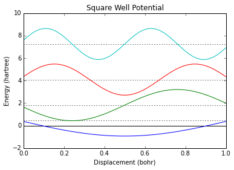

```python
square_well = Schrod1d(lambda x: 0*x,m=10)
square_well.plot(4,titlestring="Square Well Potential")
```

We can similarly redefine the Harmonic Oscillator potential.

```python
ho = Schrod1d(lambda x: x**2,start=-3,end=3)
ho.plot(6,titlestring="Harmonic Oscillator")
```

[output not shown]

# Speeding Python: Timeit, Profiling, Cython, SWIG, and PyPy

The first rule of speeding up your code is not to do it at all. As Donald Knuth said:

> "We should forget about small efficiencies, say about 97% of the time: premature optimization is the root of all evil."

The second rule of speeding up your code is to only do it if you really think you need to do it. Python has two tools to help with this process: a timing program called **timeit**, and a very good code profiler. We will discuss both of these tools in this section, as well as techniques to use to speed up your code once you know it's too slow.

## Timeit

**timeit** helps determine which of two similar routines is faster. Recall that some time ago we wrote a factorial routine, but also pointed out that Python had its own routine built into the math module. Is there any difference in the speed of the two? **timeit** helps us determine this. For example, **timeit** tells how long each method takes:

```python
%timeit factorial(20)
```

The little % sign that we have in front of the timeit call is an example of an IPython magic function (see [IPython tutorial](http://ipython.org/ipython-doc/dev/interactive/tutorial.html)).

```python
%timeit fact(20)
```

## Profiling

Profiling complements what **timeit** does by splitting the overall timing into the time spent in each function. It can give us a better understanding of what our program is really spending its time on.

Suppose we want to create a list of even numbers. Our first effort yields this:

```python
def evens(n):
    "Return a list of even numbers below n"
    l = []
    for x in range(n):
        if x % 2 == 0:
            l.append(x)
    return l
```

Is this code fast enough? We find out by running the Python profiler on a longer run:

```python
import cProfile
cProfile.run('evens(100000)')
```

```python
def evens2(n):
    "Return a list of even numbers below n"
    return [x for x in range(n) if x % 2 == 0]
```

```python
import cProfile
cProfile.run('evens2(100000)')
```

## Other Ways to Speed Python

When we compared the fact and factorial functions, above, we noted that C routines are often faster because they're more streamlined. Once we've determined that one routine is a bottleneck for the performance of a program, we can replace it with a faster version by writing it in C. This is called *extending* Python, and there's a [good section in the standard documents](http://docs.python.org/2/extending/extending.html). This can be a tedious process if you have many different routines to convert. Fortunately, there are several other options.

[Swig](http://swig.org/) (the simplified wrapper and interface generator) is a method to generate binding not only for Python but also for Matlab, Perl, Ruby, and other scripting languages. Swig can scan the header files of a C project and generate Python binding for it. Using Swig is substantially easier than writing the routines in C.

[Cython](http://www.cython.org/) is a C-extension language. You can start by compiling a Python routine into a shared object libraries that can be imported into faster versions of the routines. You can then add additional static typing and make other restrictions to further speed the code. Cython is generally easier than using Swig.

[PyPy](http://pypy.org/) is the easiest way of obtaining fast code. PyPy compiles Python to a subset of the Python language called RPython that can be efficiently compiled and optimized. Over a wide range of tests, PyPy is [roughly 6 times faster than the standard Python Distribution](http://speed.pypy.org/).

## Conclusion of the Python Overview

There is, of course, much more to the language than I've covered here. I've tried to keep this brief enough so that you can jump in and start using Python to simplify your life and work. My own experience in learning new things is that the information doesn't "stick" unless you try and use it for something in real life.

You will no doubt need to learn more as you go. I've listed several other good references, including the [Python Tutorial](http://docs.python.org/2/tutorial/) and [Learn Python the Hard Way](http://learnpythonthehardway.org/book/). Additionally, now is a good time to start familiarizing yourself with the [Python Documentation](http://docs.python.org/2.7/), and, in particular, the [Python Language Reference](http://docs.python.org/2.7/reference/index.html).

# Learning Resources

- [Official Python Documentation](http://docs.python.org/2.7), including
  - [Python Tutorial](http://docs.python.org/2.7/tutorial)
  - [Python Language Reference](http://docs.python.org/2.7/reference)
- If you're interested in Python 3, the [Official Python 3 Docs are here](http://docs.python.org/3/).
- [IPython tutorial](http://ipython.org/ipython-doc/dev/interactive/tutorial.html).
- [Learn Python The Hard Way](http://learnpythonthehardway.org/book/)
- [Dive Into Python](http://www.diveintopython.net/), in particular if you're interested in Python 3.
- [Invent With Python](http://inventwithpython.com/), probably best for kids.
- [Python Functional Programming HOWTO](http://docs.python.org/2/howto/functional.html)
- [The Structure and Interpretation of Computer Programs](http://mitpress.mit.edu/sicp/full-text/book/book.html), written in Scheme, a Lisp dialect, but one of the best books on computer programming ever written.
- [Generator Tricks for Systems Programmers](http://www.dabeaz.com/generators/) Beazley's slides on just what generators can do for you.
- [Python Module of the Week](http://pymotw.com/2/contents.html) is a series going through in-depth analysis of the Python standard library in a very easy to understand way.
- [30 Python Language Features and Tricks You May Not Know About](http://sahandsaba.com/thirty-python-language-features-and-tricks-you-may-not-know.html) a list of Python features that you should know.

## Some Python topics to look at

- **IPython:** simple shell, parallel computing.
- **IPython Notebooks:** simple web interface for preparing report-like documents (*these slides are made with it!*)
- **matplotlib:** a library for scientific plotting comparable to Matlab (see also **bokeh**).
- **pandas:** efficient data handling.
- **scikit.learn:** machine learning framework and algorithms.

## Cool IPython Notebooks to look at

- Rob Johansson's [excellent notebooks](http://jrjohansson.github.io/), including [Scientific Computing with Python](https://github.com/jrjohansson/scientific-python-lectures) and [Computational Quantum Physics with QuTiP](https://github.com/jrjohansson/qutip-lectures) lectures;
- [XKCD style graphs in matplotlib](http://nbviewer.ipython.org/url/jakevdp.github.com/downloads/notebooks/XKCD_plots.ipynb);
- [A collection of Notebooks for using IPython effectively](https://github.com/ipython/ipython/tree/master/examples/notebooks#a-collection-of-notebooks-for-using-ipython-effectively)
- [A gallery of interesting IPython Notebooks](https://github.com/ipython/ipython/wiki/A-gallery-of-interesting-IPython-Notebooks)
- [Cross-disciplinary computational analysis IPython Notebooks From Hadoop World 2012](https://github.com/invisibleroads/crosscompute-tutorials)
- [Quantites](http://nbviewer.ipython.org/urls/raw.github.com/tbekolay/pyconca2012/master/QuantitiesTutorial.ipynb) Units in Python.
  - [Another units module is here](http://www.southampton.ac.uk/~fangohr/blog/)